# 01 Cloning a Github Repo from terminal

## Cloning a github repo to your local machine

28th August 2022

This is a small example on how to download any file from a Github repo. We will describe how to clone an entire repository and also how to download a single file onto your laptop.

### 1. Download .csv file from Github

Using **git clone**

We use the **git clone** command to create a copy or clone an existing target repository in a new directory. The original repository will be stored on the remote machine or local file system with accessible supported protocols

#### 1.1 Cloning an entire repository

To make a clone of an existing Git repository, you use GIt clone command.

[figure not shown]

As displayed in the above screeshot, got to the Github repo and select **code >clone > Https** Unde this tab, you will be cable to **copy** the URL to use it in the git clone command

https://github.com/Pablo-source/NHSE-Midlands-System-Improvement.git

Then we only have to use git clone with this URL in the Terminal

Now, type in “git clone https://github.com/Pablo-source/NHSE-Midlands-System-Improvement.git “and hit Enter

```python
git clone https://github.com/Pablo-source/NHSE-Midlands-System-Improvement.git
```

This will download the entire Repo content onto your computer

It is important to notice that the above command will download the repo conent to your working directory, if you would like to download it to a different location on your machine, you need to use **"wget -P existing_directory"**

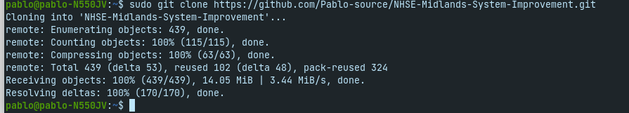

#### 1.2 Cloning a specific file from a Github repo

First we will have installed wget **sudo apt get install wget**

In the exemple below, we download a specific .csv file from a Github repo using wget to the Downloads folder in our machine

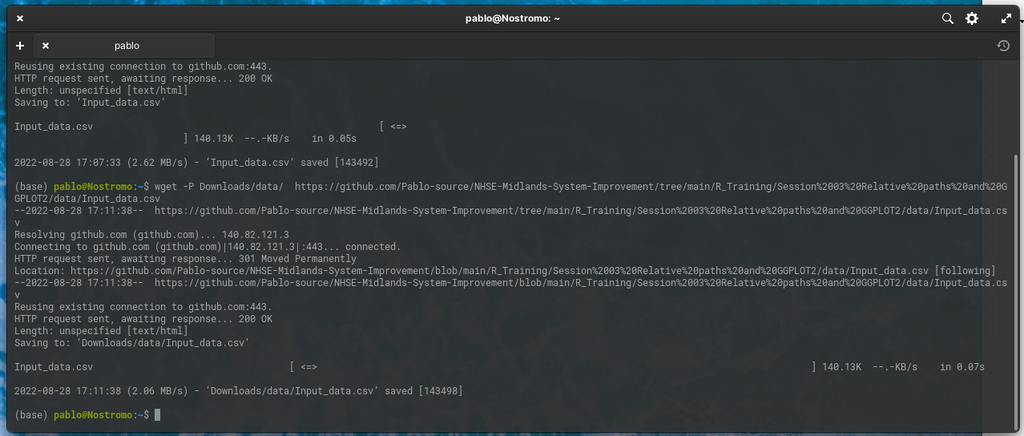